# Настройка файловых служб Samba

Лабораторная работа №14

Элсаиед Адел

Российский университет дружбы народов, Москва, Россия

7 января 2026

# Цели и задачи работы

## Цель лабораторной работы

Приобретение навыков настройки доступа групп пользователей к общим ресурсам по протоколу SMB, а также монтирования Samba-ресурса на клиенте и автоматизации конфигурации через provisioning.

# Выполнение работы

## Настройка Samba-сервера: конфигурация smb.conf

На сервере настроена рабочая группа и создан ресурс **sambashare**, публикующий каталог `/srv/sambashare`.  
Запись разрешена пользователям группы `sambagroup`.

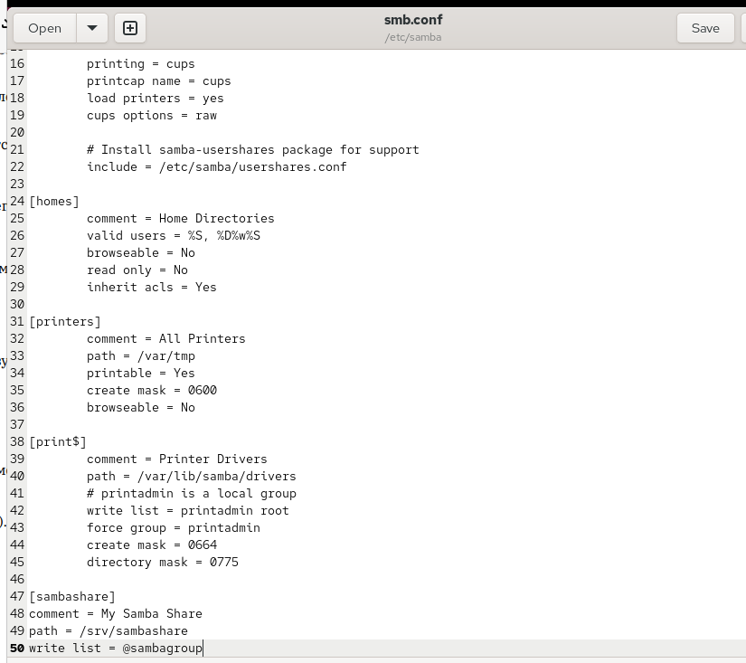

Конфигурация smb.conf и ресурс sambashare

## Проверка публикации ресурса

Проверка доступных ресурсов выполнена утилитой `smbclient`.  
Подтверждена доступность общего ресурса `sambashare`.

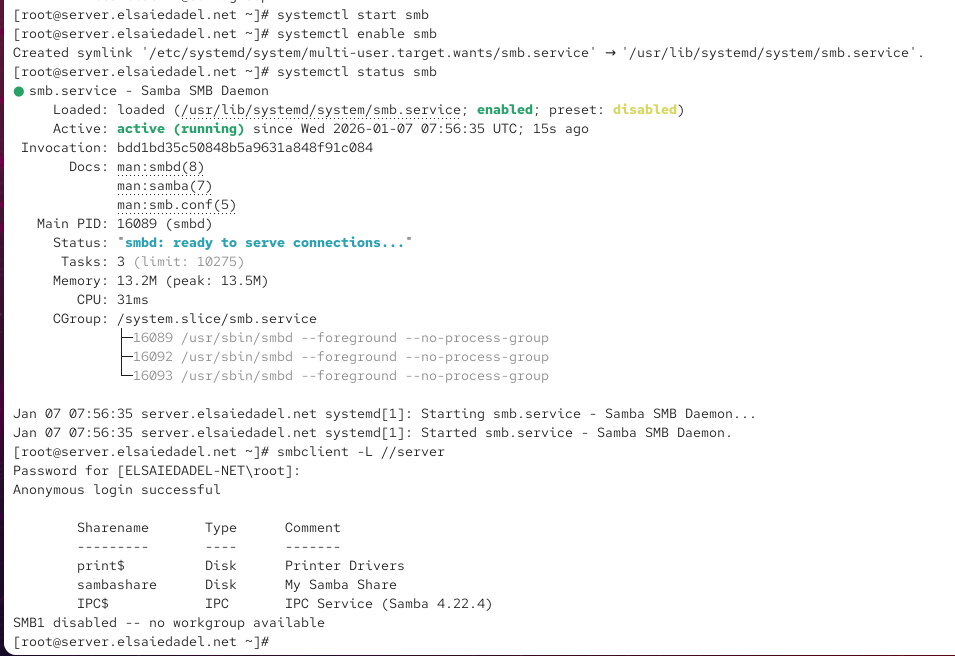

Проверка ресурсов через smbclient

## Firewalld на сервере: сервис Samba

Изучен профиль firewalld для Samba и определены порты, необходимые для работы SMB (TCP 139/445).

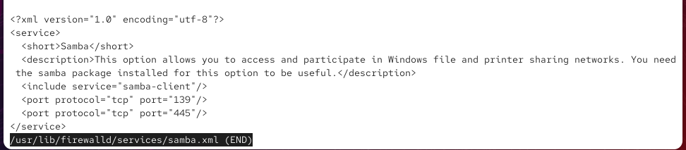

Профиль firewalld для Samba

## Доступ и SELinux на сервере

Выполнено: - разрешение сервиса Samba в firewalld; - настройка прав на каталог `/srv/sambashare` на уровне группы; - назначение SELinux-контекста `samba_share_t`; - включение boolean для экспорта ресурса на чтение/запись.

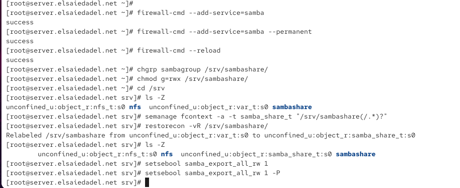

Права, SELinux-контекст и настройки сервера

## Проверка записи на сервере

Под пользователем выполнено создание тестового файла в `/srv/sambashare`.  
Подтверждено корректное наследование владельца и группы.

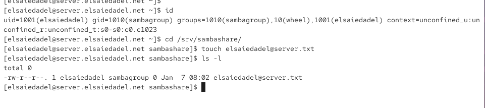

Создание тестового файла на сервере

## Клиент: firewalld и подготовка окружения

На клиенте: - изучен профиль firewalld для `samba-client`; - разрешён сервис `samba-client`; - подготовлена группа `sambagroup` и добавлен пользователь.

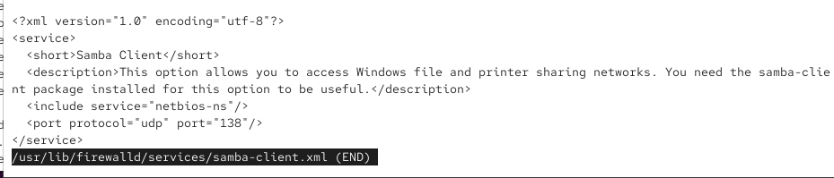

Профиль firewalld samba-client

## Клиент: настройка firewalld

Сервис `samba-client` разрешён во временной и постоянной конфигурации.  
Выполнена перезагрузка правил firewalld.

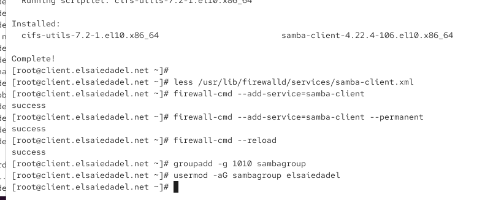

Настройка firewalld на клиенте

## Клиент: настройка рабочей группы

В `/etc/samba/smb.conf` на клиенте задана рабочая группа, соответствующая серверу.

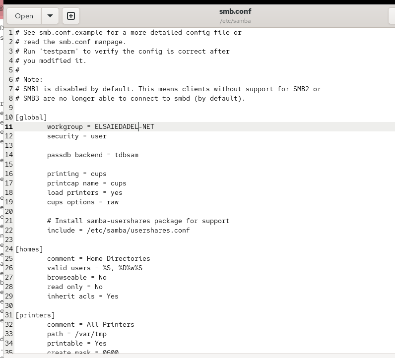

Рабочая группа в smb.conf на клиенте

## Клиент: просмотр ресурсов (анонимно и по пользователю)

Проверен список ресурсов сервера: - в анонимном режиме; - под учётной записью пользователя (аутентифицировано).

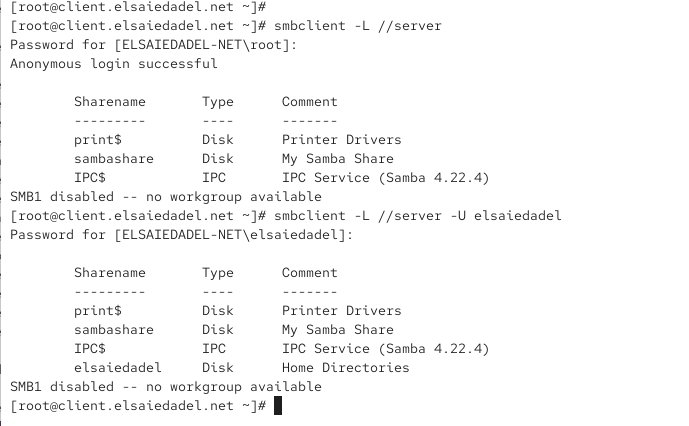

Просмотр ресурсов сервера с клиента

## Клиент: ручное монтирование ресурса

Ресурс `//server/sambashare` смонтирован в `/mnt/samba`.  
Тип монтирования — `cifs`, параметры подключения применены корректно.

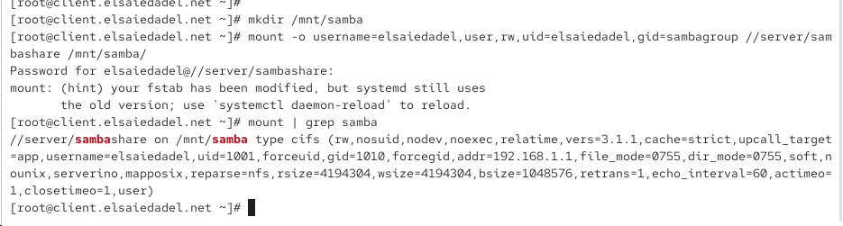

Ручное монтирование Samba-ресурса

## Клиент: проверка записи на смонтированном ресурсе

В каталоге `/mnt/samba` создан тестовый файл.  
Подтверждена возможность записи пользователем на сетевой ресурс.

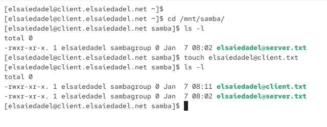

Проверка записи на ресурсе

## Клиент: файл учётных данных

Для исключения хранения пароля в явном виде подготовлен файл `/etc/samba/smbusers` с ограниченными правами доступа.

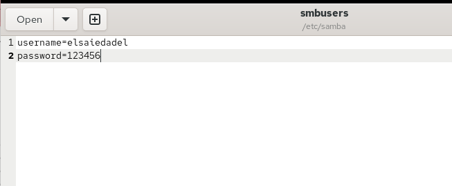

Файл smbusers

## Клиент: автомонтирование через /etc/fstab

В `/etc/fstab` добавлена строка для монтирования CIFS с использованием: - `credentials=/etc/samba/smbusers`; - `uid` и `gid` для согласования прав; - `_netdev` для монтирования после инициализации сети.

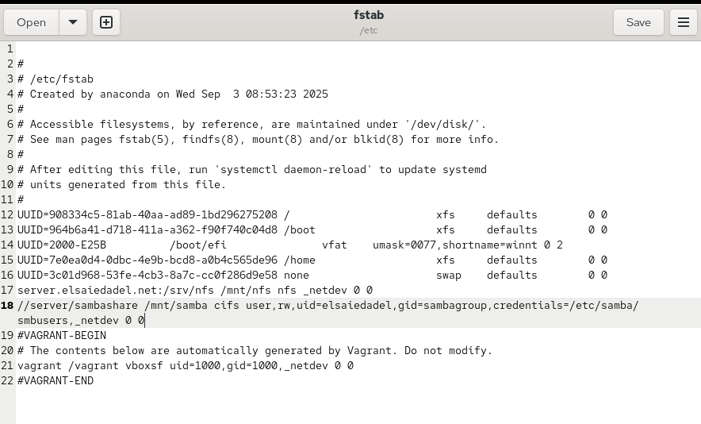

Запись в /etc/fstab

## Клиент: проверка mount -a

Выполнено монтирование всех файловых систем из `/etc/fstab`.  
Подтверждено, что Samba-ресурс монтируется корректно.

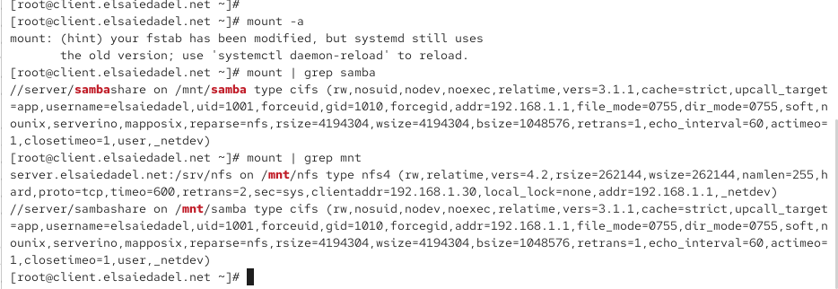

Результат mount -a и список монтирований

## Server: подготовка provisioning-окружения

На сервере подготовлена структура `/vagrant/provision/server/smb/...` и сохранён эталонный `smb.conf` для последующего развёртывания через скрипт.

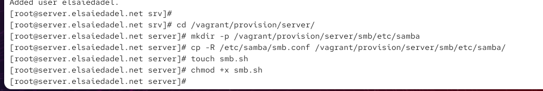

Подготовка provisioning на server

## Server: provisioning-скрипт smb.sh

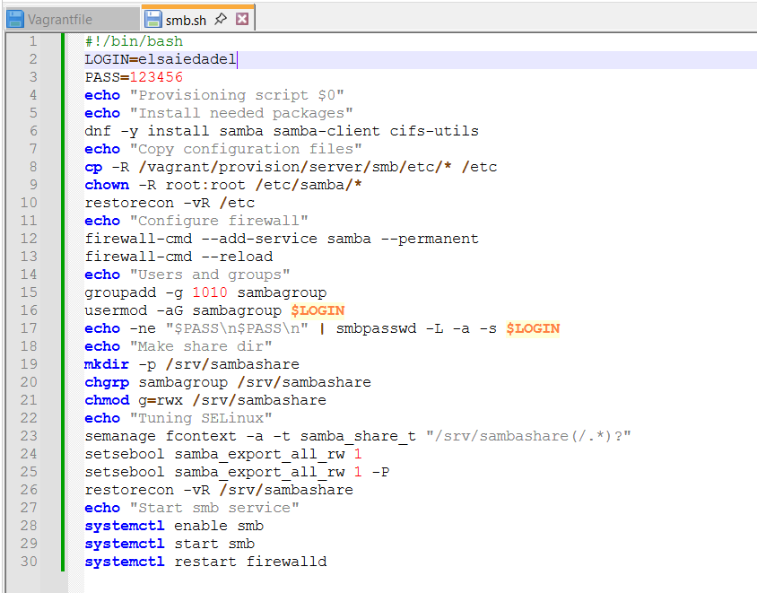

Скрипт smb.sh для server

## Client: подготовка provisioning-окружения

На клиенте подготовлена структура `/vagrant/provision/client/smb/...` и сохранены файлы `smb.conf` и `smbusers`.

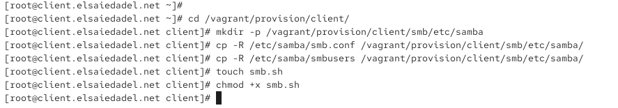

Подготовка provisioning на client

## Client: provisioning-скрипт smb.sh

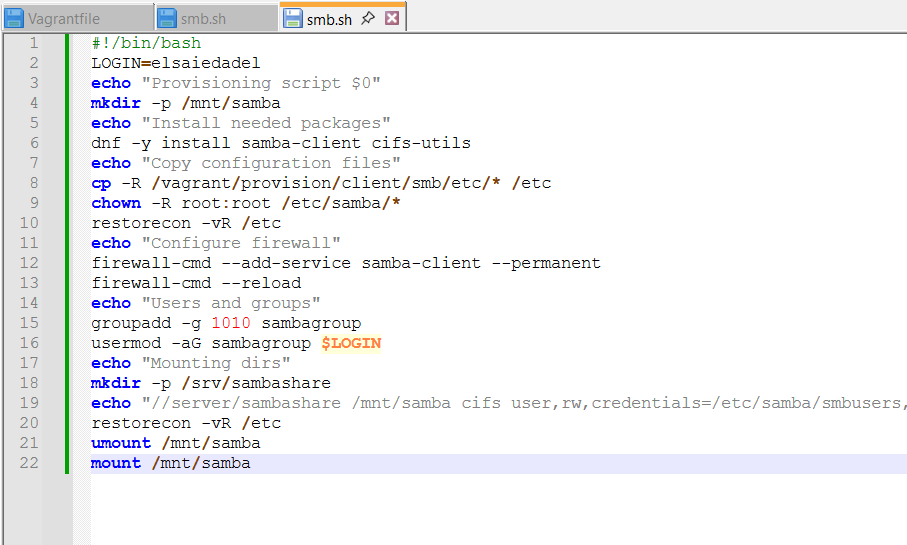

Скрипт smb.sh для client

# Выводы

## Вывод

Выполнена настройка Samba-сервера и клиента: опубликован общий ресурс, настроены права доступа, firewalld и SELinux, выполнено ручное и автоматическое монтирование на клиенте. Реализована автоматизация конфигурации через provisioning-скрипты, обеспечивающая воспроизводимое развёртывание стенда и корректный доступ пользователей к разделяемым данным.